# PS1

A possible disadvantage in using facetting is that since the points are on separate plots, direct comparisons might not be as straight forward.

When having a larger dataset, facetting might be less straight forward than color aesthetic.

2.3.4 nrow stands for the number of rows and ncol stands for the number of columns.

facet_grid() does not have nrow and ncol since the number of rows and columns are equal to the number of unique levels in the row/column variables.

2.3.5

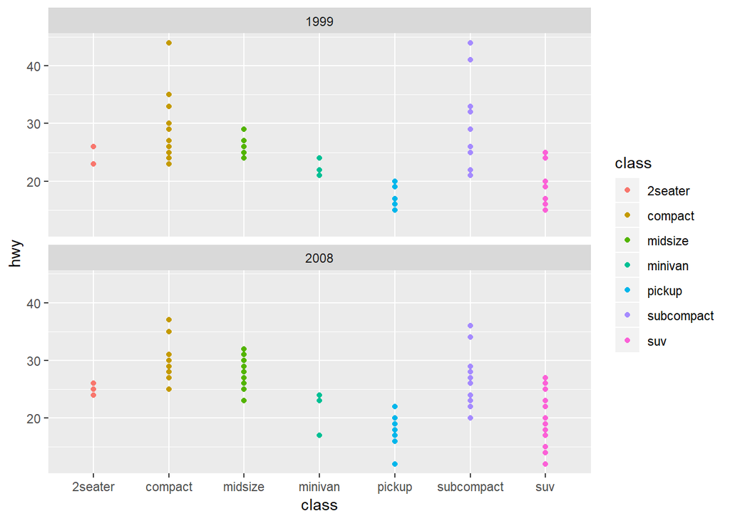

```r
ggplot(data=mpg)+
  geom_point(mapping=aes(x=class,y=hwy,color=class))+
  facet_wrap(vars(year),nrow=2)
```

2.3.6

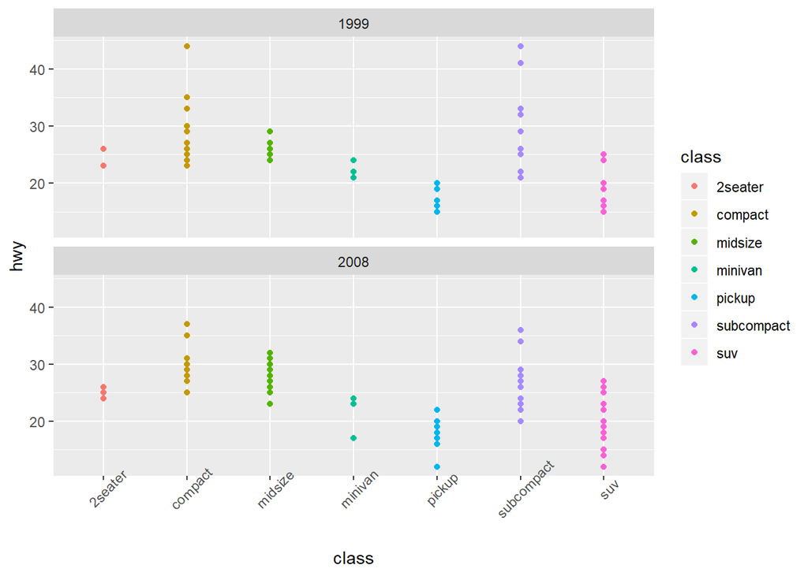

```r
ggplot(data=mpg)+
  geom_point(mapping=aes(x=class,y=hwy,color=class))+
  facet_wrap(vars(year),nrow=2)+
  theme(axis.text.x = element_text(angle=45))
```

2.3.7

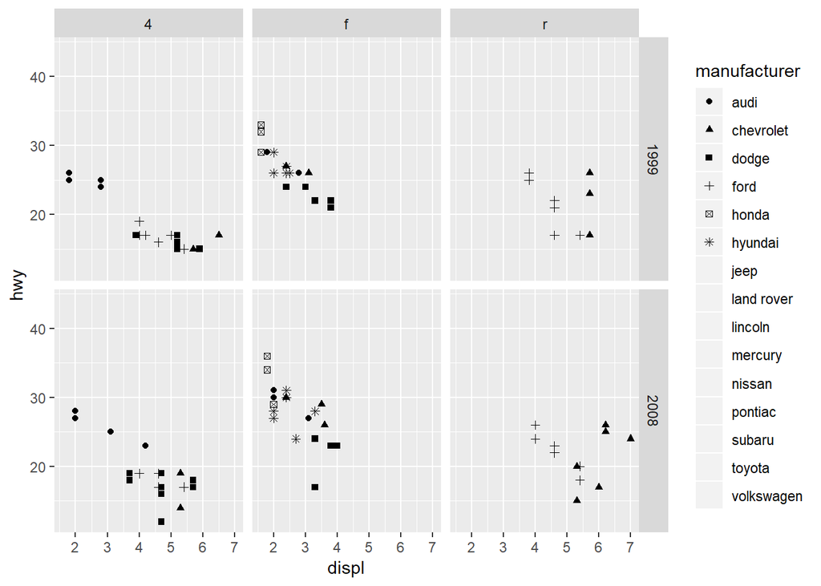

```r
ggplot(data=mpg)+
  geom_point(mapping=aes(x=displ,y=hwy,shape=manufacturer))+
  facet_grid(year~drv)
```

I think many manufactures are missing because the function ggplot() displays no more than 6 different symbols.

2.3.8

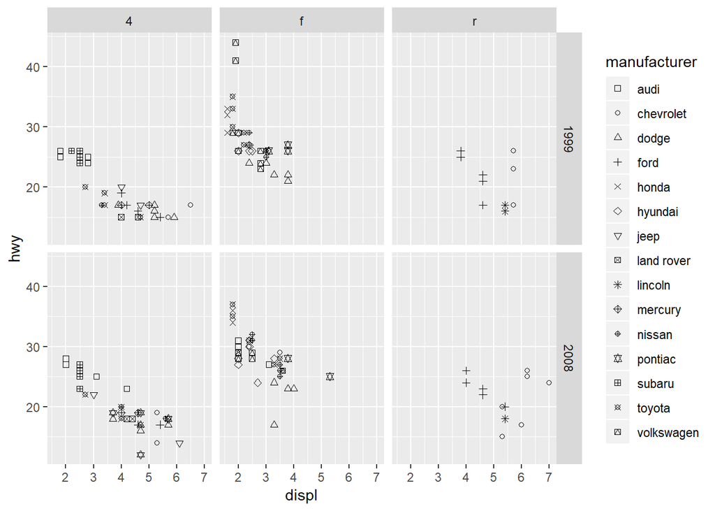

```r
ggplot(data=mpg)+
  geom_point(mapping=aes(x=displ,y=hwy,shape=manufacturer))+
  facet_grid(year~drv)+
  scale_shape_manual(values=0:15)
```